# 2-8 분산 분석

# 2-8 분산 분석(ANOVA, Analysis of Variance)

서로 다른 범주에 속한 모집단의 평균 $\mu_0, \mu_1, ... \mu_k$ 동일한지 파악합니다.

$H_0$: $\mu_0 = \mu_1 = ... \mu_k$

$H_1$: $\mu_0, \mu_1, ... \mu_k$에서 동일하지 않는 것이 존재한다.

이 때 범주형 변수를 요인(factor)라고 합니다.

분산분석은

범주형를 가변수화 하여 모집단의 평균을 추정하는 선형 회귀 모델의 유의미성을 검정하는 과정과 유사합니다.

선형 회귀 모델에서 다루었던 제곱합의 성질을 통해, 유도했던 F-test를 적용한 것입니다.

> $SST = SSR + SSE$

> $F = \frac{SSR / (p - 1)}{SSE / (n - p)} \sim F(p - 1, n - p)$, $p$: 회귀 모델의 모수의 수, $n$: 표본수

이 가설 검정에 응용한 것입니다.

그리고, 분산분석은 선형 회귀 모델의 가정을 따라갑니다.

- 서로 다른 범주에 모집단들의 분산은 동일 하다. (오차의 분산은 독립 변수와 상관없이 일정해야 합니다.)
- 서로 다른 범주에 모집단은 정규 분포를 따릅니다. (오차는 정규분포를 따라야 합니다.

## 1. 일원분산분석 (Oneway ANOVA)

단일 요인에 대한 분산분석입니다.

데이터셋을 만들어봅니다.

```r
library(dplyr)

# 설정 값
mu <- list(A = 0.3, B = 0.3, C = 0.3)
sig <- 0.2
n <- list(A = 30, B = 25, C = 35)

# 난수 생성 및 데이터프레임 결합
set.seed(123)
df_ind <- bind_rows(
  data.frame(X = rnorm(n$A, mean = mu$A, sd = sig), factor = 'A'),
  data.frame(X = rnorm(n$B, mean = mu$B, sd = sig), factor = 'B'),
  data.frame(X = rnorm(n$C, mean = mu$C, sd = sig), factor = 'C')
)

# 결과 출력
print(head(df_ind))
```

|  | X | factor |
| --- | --- | --- |
| 1 | 0.1879049 | A |
| 2 | 0.2539645 | A |
| 3 | 0.6117417 | A |
| 4 | 0.3141017 | A |
| 5 | 0.3258575 | A |
| 6 | 0.6430130 | A |

```r
# 설정 값
mu <- list(A = 0.3, B = 0.5, C = 0.7)
sig <- 0.2
n <- list(A = 30, B = 25, C = 35)

# 난수 생성 및 데이터프레임 결합
set.seed(123)
df_dep <- bind_rows(
  data.frame(X = rnorm(n$A, mean = mu$A, sd = sig), factor = 'A'),
  data.frame(X = rnorm(n$B, mean = mu$B, sd = sig), factor = 'B'),
  data.frame(X = rnorm(n$C, mean = mu$C, sd = sig), factor = 'C')
)

# 결과 출력
print(head(df_dep))
```

|  | X | factor |
| --- | --- | --- |
| 1 | 0.1879049 | A |
| 2 | 0.2539645 | A |
| 3 | 0.6117417 | A |
| 4 | 0.3141017 | A |
| 5 | 0.3258575 | A |
| 6 | 0.6430130 | A |

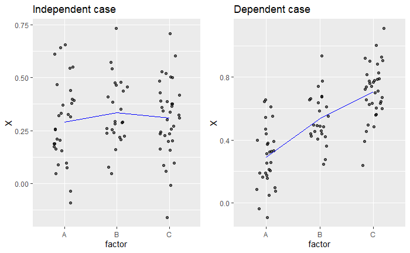

```r
# 독립 사례 그래프 생성
p1 <- ggplot(df_ind, aes(x = factor, y = X)) +
  geom_point(position = position_jitter(width = 0.2), alpha = 0.6) +
  stat_summary(fun = mean, geom = "line", aes(group = 1), color = "blue") +
  ggtitle("Independent case")

# 종속 사례 그래프 생성
p2 <- ggplot(df_dep, aes(x = factor, y = X)) +
  geom_point(position = position_jitter(width = 0.2), alpha = 0.6) +
  stat_summary(fun = mean, geom = "line", aes(group = 1), color = "blue") +
  ggtitle("Dependent case")

# 그래프 표시
library(gridExtra)
grid.arrange(p1, p2, ncol = 2)
```

**[Ex.1]**

df_ind에서 factor 에 대한 X의 모집단에 대한 분산분석을 합니다.

```r
library(stats)

# ANOVA 수행
lm_model <- lm(X ~ factor, data = df_ind)
anova_result <- anova(lm_model)

# 결과 출력
print(anova_result)
```

```
Analysis of Variance Table

Response: X
          Df  Sum Sq  Mean Sq F value Pr(>F)
factor     2 0.02779 0.013893  0.4306 0.6515
Residuals 87 2.80709 0.032265
```

$SST = SSR + SSE$

$\sum_{i \in factor}\sum_{j=1}^{n_i}{\left(y_{ij} - \bar{y}\right)^2} = \sum_{i \in factor}\sum_{j=1}^{n_i}{\left(\bar{y_i} - \bar{y}\right)^2} + \sum_{i \in factor}\sum_{j=1}^{n_i}{\left(y_{ij} - \bar{y_{i}}\right)^2}$

```r
# 제곱합 계산 함수 정의
ss <- function(v) {
  sum(v ^ 2)
}

# 전체 평균
overall_mean <- mean(df_ind$X)

# 그룹별 평균
group_means <- df_ind %>%
  group_by(factor) %>%
  mutate(group_mean = mean(X)) %>%
  ungroup()

# SST, SSR, SSE 계산
sst <- ss(df_ind$X - overall_mean)
ssr <- ss(group_means$group_mean - overall_mean)
sse <- ss(df_ind$X - group_means$group_mean)

# 자유도 계산
df_ssr <- 3 - 1
df_sse <- nrow(df_ind) - 3

# F 검정 통계량 계산
F <- (ssr / df_ssr) / (sse / df_sse)

# p-value 계산
pvalue <- pf(F, df_ssr, df_sse, lower.tail = FALSE)

# 결과 출력
cat("검정통계량(F):", F, ", pvalue:", pvalue, "\n")
```

```
검정통계량(F): 0.4305905 , pvalue: 0.651503
```

```r
cat("SST:", sst, ", SSR:", ssr, ", SSE:", sse, "\n")
```

```
SST: 2.834878 , SSR: 0.02778636 , SSE: 2.807091
```

**[Ex.2]**

분산 분석에 앞서 categ의 범주에 따라 모집단이 정규분포를 따르는지 Kolmogorov-smironof 검정으로 확인하고,

Bartlett 검정을 통해 서로 등분산인지 확인합니다.

```r
library(tidyr)
# KS 테스트 함수 정의
ks_test <- function(x) {
  x_standardized <- scale(x)
  ks_result <- ks.test(x_standardized, "pnorm")
  return(data.frame(stat = ks_result$statistic, pvalue = ks_result$p.value))
}

# 그룹별 KS 테스트 수행 및 결과 결합
df_ks <- df_dep %>%
  group_by(factor) %>%
  summarize(ks_result = list(ks_test(X))) %>%
  unnest(cols = ks_result)

# 결과 출력
print(df_ks)
```

| factor | stat | pvalue |
| --- | --- | --- |
| A | 0.09105930 | 0.9454834 |
| B | 0.16227364 | 0.4766821 |
| C | 0.06895943 | 0.9922137 |

```r
# Bartlett 검정 수행
bartlett_result <- bartlett.test(X ~ factor, data = df_dep)

# 결과 출력
print(bartlett_result)
```

```
    Bartlett test of homogeneity of variances

data:  X by factor
Bartlett's K-squared = 1.0883, df = 2, p-value = 0.5803
```

```r
# 일원 분산 분석(ANOVA) 수행
anova_result <- aov(X ~ factor, data = df_dep)

# 결과 출력
summary(anova_result)
```

```
            Df Sum Sq Mean Sq F value   Pr(>F)
factor       2  2.839  1.4195   43.99 6.28e-14 ***
Residuals   87  2.807  0.0323
---
Signif. codes:  0 ‘***’ 0.001 ‘**’ 0.01 ‘*’ 0.05 ‘.’ 0.1 ‘ ’ 1
```

## 2. 이원분산분석 (Twoway ANOVA)

두 개의 요인에 대한 분산분석입니다.

**상호작용(교호작용)**

두 요인이 작용하여 종속 변수에 미치는 영향이 개별적인 영향의 합으로 설명되지 않는 현상

※ 교호작용은 교호항 마다 두 개이상의 관측치가 있어야 합니다.

교호작용이 존재하는 데이터셋을 만들어 봅니다.

```r
# 설정 값
mu <- list(
  `A_1` = 0.2, `A_2` = 0.3, `A_3` = 0.4,
  `B_1` = 0.3, `B_2` = 0.4, `B_3` = 0.2
)
sig <- 0.2
n <- list(
  `A_1` = 15, `A_2` = 25, `A_3` = 20,
  `B_1` = 20, `B_2` = 30, `B_3` = 25
)

# 난수 생성 및 데이터프레임 결합
set.seed(123)
df_two <- bind_rows(
  data.frame(X = rnorm(n$`A_1`, mean = mu$`A_1`, sd = sig), factor_1 = 'A', factor_2 = '1'),
  data.frame(X = rnorm(n$`A_2`, mean = mu$`A_2`, sd = sig), factor_1 = 'A', factor_2 = '2'),
  data.frame(X = rnorm(n$`A_3`, mean = mu$`A_3`, sd = sig), factor_1 = 'A', factor_2 = '3'),
  data.frame(X = rnorm(n$`B_1`, mean = mu$`B_1`, sd = sig), factor_1 = 'B', factor_2 = '1'),
  data.frame(X = rnorm(n$`B_2`, mean = mu$`B_2`, sd = sig), factor_1 = 'B', factor_2 = '2'),
  data.frame(X = rnorm(n$`B_3`, mean = mu$`B_3`, sd = sig), factor_1 = 'B', factor_2 = '3')
)

# 결과 출력
print(head(df_two))
```

|  | X | factor_1 | factor_2 |
| --- | --- | --- | --- |
| 1 | 0.08790487 | A | 1 |
| 2 | 0.15396450 | A | 1 |
| 3 | 0.51174166 | A | 1 |
| 4 | 0.21410168 | A | 1 |
| 5 | 0.22585755 | A | 1 |
| 6 | 0.54301300 | A | 1 |

교호작용이 있다면,

factor_1와 factor_2 로 구분하여 평균에 대한 그래프를 factor_2의 항목을 x축에 종속 변수의 평균을 y축에, 그리고 factor_1으로 선을 구분하여,

즉 아래와 같이 직선 그래프로 출력하면,

factor_1이 A일 때와 factor_1이 B일 때, factor_2 별 성향이 다르다는 것을 확인 할 수 있습니다.

이렇다면, factor_1과 factor_2의 개별의 평균만으로 설명하기 어렵게 됩니다.

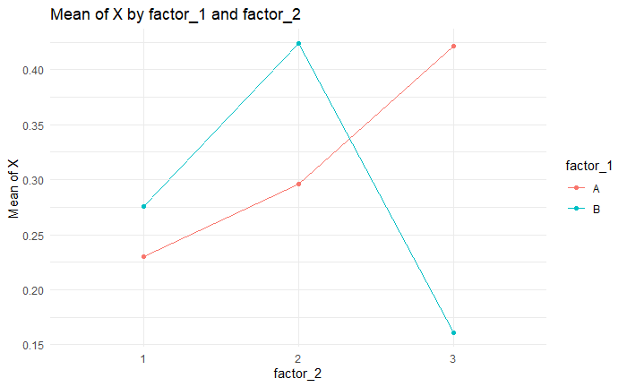

```r
# 각 그룹별 평균 계산
df_mean <- df_two %>%
  group_by(factor_1, factor_2) %>%
  summarize(mean_X = mean(X), .groups = 'drop')

# 선 그래프 생성
ggplot(df_mean, aes(x = factor_2, y = mean_X, color = factor_1, group = factor_1)) +
  geom_line() +
  geom_point() +
  labs(title = "Mean of X by factor_1 and factor_2", x = "factor_2", y = "Mean of X") +
  theme_minimal()
```

**[Ex.3]**

df_two에서 X에 대한 factor1, factor2의 이원분산분석을 해봅니다.

```r
# 이원 분산 분석(ANOVA) 수행
anova_result <- aov(X ~ factor_1 + factor_2 + factor_1:factor_2, data = df_two)

# 결과 출력
summary(anova_result)
```

```
                   Df Sum Sq Mean Sq F value   Pr(>F)
factor_1            1  0.020  0.0204   0.622  0.43181
factor_2            2  0.317  0.1585   4.837  0.00943 **
factor_1:factor_2   2  0.974  0.4872  14.865 1.55e-06 ***
Residuals         129  4.228  0.0328
---
Signif. codes:  0 ‘***’ 0.001 ‘**’ 0.01 ‘*’ 0.05 ‘.’ 0.1 ‘ ’ 1
```

$SSR$ 은 아래와 같이 $SSR_{factor_1}, SSR_{factor_2}, SSR_{factor_1, factor2}$로 분해가 될 수 있습니다.

$SST = SSR_{factor_1} + SSR_{factor_2} + SSR_{factor_1, factor_2} + SSE$

$n_1$: factor1의 요인 수, $n_2$: factor2이 요인 수 라면,

교호항의 가변수를 추가 할 때에는,

> 각 범주형 변수에서 하나의 범주씩을 제외한 순서쌍으로 가변수를 만들어야 완전한 다중공선성을 피할 수 있습니다.

> 따라서 $(n_1 - 1)(n_2 - 1)$ 교호항에 대한 가변수가 추가됩니다.

SSR의 자유도는 $n_1n_2 - 1$ 입니다.

$SSR_{factor_1}$의 자유도는 $n_1 - 1$, $SSR_{factor_2}$의 자유도는 $n_2 - 1$이므로

$SSR_{factor_1, factor_2}$의 자유도는 $n_1n_2 - 1 - n_1 + 1 - n_2 + 1 = (n_1 -1)(n_2 - 1)$ 이 됩니다.

```r
# 전체 평균
X_bar <- mean(df_two$X)

# SST 계산
sst <- ss(df_two$X - X_bar)

# 그룹별 평균 계산 및 회귀 제곱합(SSR) 계산
X_prd <- df_two %>%
  group_by(factor_1, factor_2) %>%
  mutate(mean_X = mean(X)) %>%
  pull(mean_X)

ssr <- ss(X_prd - X_bar)
ssr_1 <- ss(df_two %>% group_by(factor_1) %>% mutate(mean_X = mean(X)) %>% pull(mean_X) - X_bar)
ssr_2 <- ss(df_two %>% group_by(factor_2) %>% mutate(mean_X = mean(X)) %>% pull(mean_X) - X_bar)
ssr_12 <- ssr - ssr_1 - ssr_2

# 오차 제곱합(SSE) 계산
sse <- ss(df_two$X - X_prd)

# 결과 출력
cat("SST:", sst, "\n")
```

```
SST: 5.540321
```

```r
cat("SSR:", ssr, "\n")
```

```
SSR: 1.311923
```

```r
cat("SSR_1:", ssr_1, "\n")
```

```
SSR_1: 0.02038331
```

```r
cat("SSR_2:", ssr_2, "\n")
```

```
SSR_2: 0.3199556
```

```r
cat("SSR_12:", ssr_12, "\n")
```

```
SSR_12: 0.9715839
```

```r
cat("SSE:", sse, "\n")
```

```
SSE: 4.228398
```

```r
# 자유도 계산
n1 <- 2
n2 <- 3
df_ssr_12 <- (n1 - 1) * (n2 - 1)
df_sse <- nrow(df_two) - n1 * n2

# F 검정 통계량 계산
F <- (ssr_12 / df_ssr_12) / (sse / df_sse)

# 결과 출력
cat("F 검정 통계량:", F, "\n")
```

```
F 검정 통계량: 14.82054
```